# The Music Study

Joey Stanley

04/01/2019

```r
library(tidyverse)
library(readxl)
library(ggthemes)
```

## 0.1 Read in the full data

Unlike the frequency portion, all my music data is in one file, `Music-Quantified.xlsx`, specifically, the 2nd sheet. It’s not in a tidy format, so I need to to a bit of data cleaning before I can work on it.

```r
hymns_quantified <- read_excel("../data/Music-Quantified.xlsx", sheet = "Raw Data",

                               # Column names were spread over two rows, so provide my own
                               skip = 2,
                               col_names = c("sop_typed",  "sop_num",  "sop_dur",  "sop_val",
                                             "alto_typed", "alto_num", "alto_dur", "alto_val",
                                             "ten_typed",  "ten_num",  "ten_dur",  "ten_val",
                                             "bass_typed", "bass_num", "bass_dur", "bass_val")) %>%
    # Add a unique id per row
    rowid_to_column("id") %>%

    # New hymns were indicated with a merged cell across all of them.
    # First, locate those rows
    mutate(hymn = if_else(str_detect(sop_typed, "—"), sop_typed, NULL)) %>%
    # Fill them down
    fill(hymn) %>%
    # Remove those rows
    filter(is.na(sop_typed) | sop_typed != hymn) %>%

    # Get the hymn title and number
    mutate(hymn = if_else(str_detect(hymn, "^H"), str_sub(hymn, 6), hymn)) %>%
    separate(hymn, c("hymn_num", "title"), sep = "—", convert = TRUE) %>%

    # Add a unique id per row per hymn. Remove the last row since it was just the filler
    group_by(hymn_num, title) %>%
    mutate(song_row_id = row_number()) %>%
    add_count() %>%
    filter(song_row_id != n) %>%
    select(-n) %>%
    ungroup() %>%

    # There's an error in the Excel Spreadsheet. If the note is blank, the default value was a zero instead of an empty string.
    # I fixed this in Hymn 6, and it worked fine, but I don't want to mess with the original. So I'll modify it here.
    mutate_at(vars(sop_val,  sop_num),  funs(ifelse(is.na(sop_typed),  NA, .))) %>%
    mutate_at(vars(alto_val, alto_num), funs(ifelse(is.na(alto_typed), NA, .))) %>%
    mutate_at(vars(ten_val,  ten_num),  funs(ifelse(is.na(ten_typed),  NA, .))) %>%
    mutate_at(vars(bass_val, bass_num), funs(ifelse(is.na(bass_typed), NA, .))) %>%

    select(id, song_row_id, hymn_num, title, everything()) %>%
    print()
```

```
## # A tibble: 21,707 × 20
##       id song_row_id hymn_num title sop_typed sop_num sop_dur sop_val alto_typed
##    <int>       <int>    <int> <chr> <chr>       <dbl>   <dbl>   <dbl>      <dbl>
##  1     2           1        1 The … 0              NA      NA      NA          0
##  2     3           2        1 The … 5               7       1       7          3
##  3     4           3        1 The … 5               7       2      14          3
##  4     5           4        1 The … 3               4       1       4          1
##  5     6           5        1 The … 8              12       2      24          3
##  6     7           6        1 The … <NA>           NA      NA      NA         NA
##  7     8           7        1 The … 7              11       1      11          2
##  8     9           8        1 The … 6               9       1       9          1
##  9    10           9        1 The … 10             16       1      16          4
## 10    11          10        1 The … 9              14       1      14          4
## # … with 21,697 more rows, and 11 more variables: alto_num <dbl>,
## #   alto_dur <dbl>, alto_val <dbl>, ten_typed <dbl>, ten_num <dbl>,
## #   ten_dur <dbl>, ten_val <dbl>, bass_typed <dbl>, bass_num <dbl>,
## #   bass_dur <dbl>, bass_val <dbl>
```

So the `hymns_quantified` object is now a relatively tidy version of the full spreadsheet.

### 0.1.1 Key Signatures and Transposition Values

When I typed this data out, I did so sort of transposing them. This means I mentaally converted them into a single key signature. To reproject these numbers into actual notes, I had a key signature numbers at the top of each hymn that would be added to the values. In most cases, it was the same for all four parts (the key of D was 2 2 2 2), but in some cases, like in the key of G, it was easier to do like 7 -5 7 -5. So I need to pull those numbers out.

In the original spreadsheet, these numbers were merged cells underneath the hymn name. Now that the data has been cleaned up in R, they are currently the first row in each hymn.

```r
transpose_values <- hymns_quantified %>%
    group_by(title, hymn_num) %>%
    summarize(sop_key  = first(sop_typed),
              alto_key = first(alto_typed),
              ten_key  = first(ten_typed),
              bass_key = first(bass_typed)) %>%
    arrange(hymn_num) %>%
    ungroup() %>%
    print()
```

```
## # A tibble: 363 × 6
##    title                          hymn_num sop_key alto_key ten_key bass_key
##    <chr>                             <int> <chr>      <dbl>   <dbl>    <dbl>
##  1 The Morning Breaks                    1 0              0       0        0
##  2 The Spirit of God                     2 -2            -2      -2       -2
##  3 Now Let Us Rejoice                    3 2              2       2        2
##  4 Truth Eternal                         4 2              2       2        2
##  5 High on the Mountain Top              5 7             -5       7       -5
##  6 Redeemer of Israel                    6 2              2       2        2
##  7 Israel, Israel, God is Calling        7 5             -7       5       -7
##  8 Awake and Arise                       8 3              3       3        3
##  9 Come, Rejoice                         9 5              5       5        5
## 10 Come, Sing to the Lord               10 3              3       3        3
## # … with 353 more rows
```

So now I have a spreadsheet that has the transposition values for each hymn. I’ll use this later on.

For now, I can examine it. First, I can see which transposition values are the most common. I have code for doing this in R, but the information is already in the “Key Signature Lookup” sheet in the `Music-Quantified.xlsx` file.

```r
# transpose_lookup <- transpose_values %>%
#     mutate(transpose_seq = paste(sop_key, alto_key, ten_key, bass_key)) %>%
#     group_by(transpose_seq) %>%
#     summarize(n = n()) %>%
#     arrange(-n) %>%
#     print(n = 20)
transpose_lookup <- read_excel("../data/Music-Quantified.xlsx", sheet = "Key Signature Lookup") %>%
    print()
```

```
## # A tibble: 20 × 4
##    transpose_seq n_hymns key_signature notes
##    <chr>           <dbl> <chr>         <chr>
##  1 -3 -3 -3 -3         2 A             <NA>
##  2 -3 -3 9 -3          1 A             An Angel from on High (men's chorus)
##  3 -4 -4 8 -4          2 Ab            The Wintry Day, School Thy Feelings (mid…
##  4 -4 -4 -4 -4        21 Ab            <NA>
##  5 0 0 -4 -4           1 Ab            High on the Mountain Top (middle parts)
##  6 8 -4 -4 -4          2 Ab            See the Mighty Angel Flying
##  7 -2 -2 -2 -2        44 Bb            <NA>
##  8 0 0 0 0            48 C             <NA>
##  9 0 0 12 0            3 C             men's choir
## 10 0 0 8 -4            3 C             men's choir
## 11 2 2 2 2            56 D             <NA>
## 12 1 1 1 1             2 Db            <NA>
## 13 3 -9 3 -9           2 Eb            As Now We Take the Sacrament, With Humbl…
## 14 3 3 3 -9            7 Eb            <NA>
## 15 3 3 3 3            42 Eb            <NA>
## 16 5 -7 5 -7          45 F             <NA>
## 17 5 -7 5 5            1 F             Actually Dm (That Easter Morn)
## 18 5 5 5 5             2 F             Come Rejoice, Families Can be Together F…
## 19 4 -8 4 4            1 G             Actually Em (Hymn 126)
## 20 7 -5 7 -5          77 G             <NA>
```

This can be used to help identify which songs had what sequence of transpose keys.

```r
key_signature_lookup <- transpose_values %>%
    mutate(transpose_seq = paste(sop_key, alto_key, ten_key, bass_key)) %>%
    left_join(transpose_lookup, by = "transpose_seq") %>%
    select(-ends_with("key"), -notes, -n_hymns) %>%
    arrange(transpose_seq, hymn_num) %>%
    print()
```

```
## # A tibble: 363 × 4
##    title                                          hymn_num transpose_seq key_signature
##    <chr>                                             <int> <chr>         <chr>
##  1 The Spirit of God                                     2 -2 -2 -2 -2   Bb
##  2 Now We'll Sing with One Accord                       25 -2 -2 -2 -2   Bb
##  3 Joseph Smith's First Prayer                          26 -2 -2 -2 -2   Bb
##  4 O Ye Mountains High                                  34 -2 -2 -2 -2   Bb
##  5 Let Zion in Her Beauty Rise                          41 -2 -2 -2 -2   Bb
##  6 Hail to the Brightness of Zion's Glad Morning!       42 -2 -2 -2 -2   Bb
##  7 The Day Dawn Is Breaking                             52 -2 -2 -2 -2   Bb
##  8 Come, Ye Children of the Lord                        58 -2 -2 -2 -2   Bb
##  9 Battle Hymn of the Republic                          60 -2 -2 -2 -2   Bb
## 10 Come, All Ye Saints Who Dwell on Earth               65 -2 -2 -2 -2   Bb
## # … with 353 more rows
```

Out of curiosity, how many songs are there key signature?

```r
transpose_lookup %>%
    mutate(key_signature = factor(key_signature, levels = c("A", "D", "G", "C", "F",
                                                            "Bb", "Eb", "Ab", "Db"))) %>%
    group_by(key_signature) %>%
    tally(n_hymns) %>%
    print()
```

```
## # A tibble: 9 × 2
##   key_signature     n
##   <fct>         <dbl>
## 1 A                 3
## 2 D                56
## 3 G                78
## 4 C                54
## 5 F                48
## 6 Bb               44
## 7 Eb               51
## 8 Ab               26
## 9 Db                2
```

Now I’ll add all this information back into the original spreadsheet. It gets a little messy with the transposition sequence (first I had to create it, then fill down, then remove the first rnow), but then it’s not bad.

```r
# A new version of the data with the key signature information
hymns_with_keys <- hymns_quantified %>%

    # Same technique as before, but with the key signature information
    # First, locate those rows
    mutate(transpose_seq = if_else(!is.na(sop_typed) & is.na(sop_num),
                                   paste(sop_typed, alto_typed, ten_typed, bass_typed), NULL)) %>%
    # Fill them down
    fill(transpose_seq) %>%
    # Remove those rows
    filter(song_row_id != 1) %>%

    # Get the key signature with this transpose sequence
    left_join(select(key_signature_lookup, -hymn_num), by = c("title", "transpose_seq")) %>%

    # Now split up the trans_seq
    separate(transpose_seq, into = c("sop_key", "alto_key", "ten_key", "bass_key"), sep = " ") %>%
    select(id, hymn_num, title, starts_with("sop"), starts_with("alto"),
           starts_with("ten"), starts_with("bass"), everything()) %>%
    print()
```

```
## # A tibble: 21,471 × 25
##       id hymn_num title     sop_typed sop_num sop_dur sop_val sop_key alto_typed
##    <int>    <int> <chr>     <chr>       <dbl>   <dbl>   <dbl> <chr>        <dbl>
##  1     3        1 The Morn… 5               7       1       7 0                3
##  2     4        1 The Morn… 5               7       2      14 0                3
##  3     5        1 The Morn… 3               4       1       4 0                1
##  4     6        1 The Morn… 8              12       2      24 0                3
##  5     7        1 The Morn… <NA>           NA      NA      NA 0               NA
##  6     8        1 The Morn… 7              11       1      11 0                2
##  7     9        1 The Morn… 6               9       1       9 0                1
##  8    10        1 The Morn… 10             16       1      16 0                4
##  9    11        1 The Morn… 9              14       1      14 0                4
## 10    12        1 The Morn… 8              12       1      12 0                3
## # … with 21,461 more rows, and 16 more variables: alto_num <dbl>,
## #   alto_dur <dbl>, alto_val <dbl>, alto_key <chr>, ten_typed <dbl>,
## #   ten_num <dbl>, ten_dur <dbl>, ten_val <dbl>, ten_key <chr>,
## #   bass_typed <dbl>, bass_num <dbl>, bass_dur <dbl>, bass_val <dbl>,
## #   bass_key <chr>, song_row_id <int>, key_signature <chr>
```

### 0.1.2 The notes

Now I need to work on the notes. First, I’ll read in a one of the sheets in the original spreadsheet. It has all the actual music notes. Mentally, I converted each song to the key of C, so I typed them relative to this. With this and the transposition notes, I’ll be able to convert the music into actual notes.

The important part here is that if a note dipped below C, it was negative, but still in that scale. So if a C was 1 and a D is 2, a B was -7 because it was below C, but the 7th note of the scale.

```r
notes_lookup <- read_excel("../data/Music-Quantified.xlsx", sheet = "Convert Numbers") %>%
    select(-benchmark) %>%
    print()
```

```
## # A tibble: 46 × 5
##    typed actual note  octave  midi
##    <dbl>  <dbl> <chr>  <dbl> <dbl>
##  1    NA    -24 C          2    36
##  2    NA    -23 C#         2    37
##  3    NA    -22 D          2    38
##  4    NA    -21 Eb         2    39
##  5    NA    -20 E          2    40
##  6    NA    -19 F          2    41
##  7    NA    -18 F#         2    42
##  8    NA    -17 G          2    43
##  9    NA    -16 Ab         2    44
## 10    NA    -15 A          2    45
## # … with 36 more rows
```

So now I read in a spreadsheet that acts as a lookup for the relative note in the scale, the key signature, and what the actual note is. In other words, given that I typed a 3 and the key was D, I’d get an F#. Instead of matrix style, I convert this to a tall format.

```r
note_in_key_lookup <- read_excel("../data/Music-Quantified.xlsx", sheet = "Note In Key Lookup") %>%
    gather(key, value, -note) %>%
    mutate(key = factor(key, levels = c("A", "D", "G", "C", "F", "Bb", "Eb", "Ab", "Db"))) %>%
    select(key, note, value) %>%
    print()
```

```
## # A tibble: 108 × 3
##    key   note  value
##    <fct> <chr> <dbl>
##  1 A     C       2.5
##  2 A     C#      3
##  3 A     D       4
##  4 A     Eb      4.5
##  5 A     E       5
##  6 A     F       5.5
##  7 A     F#      6
##  8 A     G       6.5
##  9 A     Ab      7
## 10 A     A       1
## # … with 98 more rows
```

Now, with this data ready, I need to add that information to the full spreadsheet.

```r
# Add the note name (*_note) and the note in the scale (*_inscale) columns.
hymns_with_notes <- hymns_with_keys %>%
   # filter(hymn_num == 4) %>%

    # Get the actual note value.
    # I might be able to do this by making it tall and doing it all in one, but I'll just do this four times
    left_join(select(notes_lookup, -typed), by = c("sop_num"  = "actual")) %>%
    rename(sop_note = note, sop_octave = octave) %>%
    left_join(select(notes_lookup, -typed), by = c("alto_num" = "actual")) %>%
    rename(alto_note = note, alto_octave = octave) %>%
    left_join(select(notes_lookup, -typed), by = c("ten_num"  = "actual")) %>%
    rename(ten_note = note, ten_octave = octave) %>%
    left_join(select(notes_lookup, -typed), by = c("bass_num" = "actual")) %>%
    rename(bass_note = note, bass_octave = octave) %>%

    # Get the note in the key
    left_join(note_in_key_lookup, by = c("key_signature" = "key", "sop_note" = "note")) %>%
    rename(sop_inscale = value) %>%
    left_join(note_in_key_lookup, by = c("key_signature" = "key", "alto_note" = "note")) %>%
    rename(alto_inscale = value) %>%
    left_join(note_in_key_lookup, by = c("key_signature" = "key", "ten_note" = "note")) %>%
    rename(ten_inscale = value) %>%
    left_join(note_in_key_lookup, by = c("key_signature" = "key", "bass_note" = "note")) %>%
    rename(bass_inscale = value) %>%

    # Lower octave for tenors and basses.
    mutate(ten_octave  = ten_octave  - 1,
           bass_octave = bass_octave - 1) %>%
    select(id, hymn_num, title, key_signature,
           starts_with("sop"), starts_with("alto"), starts_with("ten"), starts_with("bass")) %>%


    # Lose the columns I don't need anymore and then reorder the columns.
    select(id, hymn_num, title, key_signature,
           ends_with("_note"), ends_with("octave"), ends_with("inscale"), ends_with("_dur")) %>%

    print()
```

```
## # A tibble: 21,471 × 20
##       id hymn_num title      key_signature sop_note alto_note ten_note bass_note
##    <int>    <int> <chr>      <chr>         <chr>    <chr>     <chr>    <chr>
##  1     3        1 The Morni… C             G        E         C        C
##  2     4        1 The Morni… C             G        E         C        C
##  3     5        1 The Morni… C             E        C         G        C
##  4     6        1 The Morni… C             C        E         A        A
##  5     7        1 The Morni… C             <NA>     <NA>      <NA>     C
##  6     8        1 The Morni… C             B        D         Ab       E
##  7     9        1 The Morni… C             A        C         A        F
##  8    10        1 The Morni… C             E        F         <NA>     <NA>
##  9    11        1 The Morni… C             D        F         A        F
## 10    12        1 The Morni… C             C        E         G        G
## # … with 21,461 more rows, and 12 more variables: sop_octave <dbl>,
## #   alto_octave <dbl>, ten_octave <dbl>, bass_octave <dbl>, sop_inscale <dbl>,
## #   alto_inscale <dbl>, ten_inscale <dbl>, bass_inscale <dbl>, sop_dur <dbl>,
## #   alto_dur <dbl>, ten_dur <dbl>, bass_dur <dbl>
```

Okay, so now I have a spreadsheet that has lots of information. The typed notes were converted into their actual note values. Those are in the `*_note` columns. After that, are the octaves those notes are in (`*_octave`). Then are the where in the scale those notes are (`*_inscale`). Last is the duration (`*_dur`).

However, because durations aren’t the same for all parts, I have to turn it tall.

```r
# I think at some point I'm going to have to turn it tall, with one note per row.
make_each_part_wide <- function(df, part) {
    abb <- if_else(nchar(part) > 4, str_sub(part, 0, 3), part)
    df %>%
        select(id, hymn_num, title, key_signature, starts_with(abb)) %>%
        rename_at(vars(starts_with(abb)), funs(str_replace(., paste0(abb, "_"), ""))) %>%
        mutate(voice = part,
               is_rest = if_else(is.na(note) & !is.na(dur), TRUE, FALSE),
               held    = if_else(is.na(note) & is_rest == FALSE, TRUE, FALSE)) %>%
        fill(note, octave, inscale, dur) %>%
        mutate(note    = replace(note,    is_rest == TRUE, NA),
               octave  = replace(octave,  is_rest == TRUE, NA),
               inscale = replace(inscale, is_rest == TRUE, NA))
}

hymns_tall <- make_each_part_wide(hymns_with_notes, "soprano") %>%
    bind_rows(make_each_part_wide(hymns_with_notes, "alto")) %>%
    bind_rows(make_each_part_wide(hymns_with_notes, "tenor")) %>%
    bind_rows(make_each_part_wide(hymns_with_notes, "bass")) %>%
    mutate(voice = factor(voice, levels = c("soprano", "alto", "tenor", "bass"))) %>%
    print()
```

```
## # A tibble: 85,884 × 11
##       id hymn_num title   key_signature note  octave inscale   dur voice is_rest
##    <int>    <int> <chr>   <chr>         <chr>  <dbl>   <dbl> <dbl> <fct> <lgl>
##  1     3        1 The Mo… C             G          4       5     1 sopr… FALSE
##  2     4        1 The Mo… C             G          4       5     2 sopr… FALSE
##  3     5        1 The Mo… C             E          4       3     1 sopr… FALSE
##  4     6        1 The Mo… C             C          5       1     2 sopr… FALSE
##  5     7        1 The Mo… C             C          5       1     2 sopr… FALSE
##  6     8        1 The Mo… C             B          4       7     1 sopr… FALSE
##  7     9        1 The Mo… C             A          4       6     1 sopr… FALSE
##  8    10        1 The Mo… C             E          5       3     1 sopr… FALSE
##  9    11        1 The Mo… C             D          5       2     1 sopr… FALSE
## 10    12        1 The Mo… C             C          5       1     1 sopr… FALSE
## # … with 85,874 more rows, and 1 more variable: held <lgl>
```

## 0.2 Visualizations

### 0.2.1 Sparklines

The main visual I’d like to do are sparklines. I think they’re the best way to show the most amount of information at once. Plus they can be easily overlapped.

So here is the spreadsheet for sparklines.

```r
sparklines <- hymns_tall %>%

    # Get the correct notes
    left_join(notes_lookup, by = c("note", "octave")) %>%
    select(-typed) %>%

    # Just one point per note
    filter(held == FALSE) %>%

    # Create a line ID for voice + hymn for geom_line
    unite(line_id, hymn_num, voice, remove = FALSE) %>%
    # Create a label for display purposes only
    mutate(label = paste0(title, " (", hymn_num, ")")) %>%

    group_by(hymn_num, voice) %>%

    # Get cumuative and relative durations
    mutate(cume_dur = lag(cumsum(dur), default = 0),
           rel_dur = cume_dur / max(cume_dur),
           # normalize the notes
           actual_z = scale(actual)) %>%
    ungroup() %>%
    print()
```

```
## # A tibble: 71,368 × 18
##       id line_id  hymn_num title  key_signature note  octave inscale   dur voice
##    <int> <chr>       <int> <chr>  <chr>         <chr>  <dbl>   <dbl> <dbl> <fct>
##  1     3 1_sopra…        1 The M… C             G          4       5     1 sopr…
##  2     4 1_sopra…        1 The M… C             G          4       5     2 sopr…
##  3     5 1_sopra…        1 The M… C             E          4       3     1 sopr…
##  4     6 1_sopra…        1 The M… C             C          5       1     2 sopr…
##  5     8 1_sopra…        1 The M… C             B          4       7     1 sopr…
##  6     9 1_sopra…        1 The M… C             A          4       6     1 sopr…
##  7    10 1_sopra…        1 The M… C             E          5       3     1 sopr…
##  8    11 1_sopra…        1 The M… C             D          5       2     1 sopr…
##  9    12 1_sopra…        1 The M… C             C          5       1     1 sopr…
## 10    13 1_sopra…        1 The M… C             B          4       7     1 sopr…
## # … with 71,358 more rows, and 8 more variables: is_rest <lgl>, held <lgl>,
## #   actual <dbl>, midi <dbl>, label <chr>, cume_dur <dbl>, rel_dur <dbl>,
## #   actual_z <dbl[,1]>
```

```r
sparklines %>%
    group_by(hymn_num, voice) %>%
    summarize(cume_dur = max(cume_dur)) %>%
    spread(voice, cume_dur) %>%
    mutate(all_match = near(soprano, alto) & near(soprano, tenor) & near(soprano, bass)) %>%
    filter(!all_match) %>%
    print()
```

```
## # A tibble: 35 × 6
## # Groups:   hymn_num [35]
##    hymn_num soprano  alto tenor  bass all_match
##       <int>   <dbl> <dbl> <dbl> <dbl> <lgl>
##  1      115    63    63    63    62   FALSE
##  2      117    84    90    90    84   FALSE
##  3      126    31.5  31.5  31.5  30.5 FALSE
##  4      155    36    37    37    36   FALSE
##  5      167    39    39    39    41   FALSE
##  6      168    32    32    34    32   FALSE
##  7      182    40    40    41    40   FALSE
##  8      183    46    46    46    46.7 FALSE
##  9      185    93   189    93    93   FALSE
## 10      186    46    47    46    45   FALSE
## # … with 25 more rows
```

```r
sparklines %>%
    count(dur)
```

```
## # A tibble: 23 × 2
##      dur     n
##    <dbl> <int>
##  1 0.167     8
##  2 0.25   2595
##  3 0.333     2
##  4 0.333   704
##  5 0.5   13718
##  6 0.667   327
##  7 0.75   2519
##  8 1     36589
##  9 1.33     27
## 10 1.5    3569
## # … with 13 more rows
```

```r
sparklines %>%
    filter(dur == 15)
```

```
## # A tibble: 0 × 18
## # … with 18 variables: id <int>, line_id <chr>, hymn_num <int>, title <chr>,
## #   key_signature <chr>, note <chr>, octave <dbl>, inscale <dbl>, dur <dbl>,
## #   voice <fct>, is_rest <lgl>, held <lgl>, actual <dbl>, midi <dbl>,
## #   label <chr>, cume_dur <dbl>, rel_dur <dbl>, actual_z <dbl[,1]>
```

I’ve checked through 163.

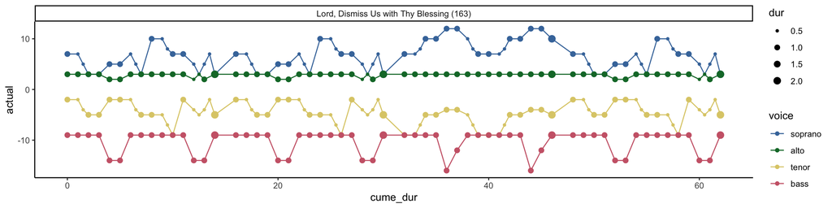

```r
sparklines %>%
    filter(hymn_num == 163) %>%
    mutate(label = paste0(title, " (", hymn_num, ")")) %>%
    ggplot(aes(cume_dur, actual, color = voice)) +
    geom_path(aes(group = voice)) +
    #geom_label(aes(size = dur, label = note)) +
    geom_point(aes(size = dur)) +
    facet_wrap(~label, ncol = 1, scales = "free") +
    scale_size_continuous(range = c(1, 3)) +
    scale_color_ptol() +
    theme_classic()
```

```r
sparklines %>%
    filter(hymn_num == 105) %>%
    group_by(voice) %>%
    summarize(sum_dur = sum(dur))
```

```
## # A tibble: 4 × 2
##   voice   sum_dur
##   <fct>     <dbl>
## 1 soprano     216
## 2 alto        216
## 3 tenor       216
## 4 bass        216
```

Here, I can get the “average” line for each part. Do to this, I’m scaling the notes per part. Unfortunately, this is a *lot* less interesting than I expected.

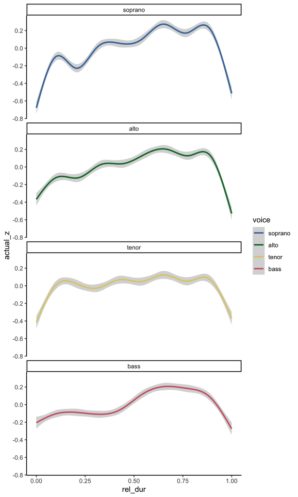

```r
sparklines %>%
    #filter(hymn_num %in% c(1:11)) %>%
    # Create a line ID for voice + hymn
    unite(line_id, hymn_num, voice, remove = FALSE) %>%
    # Create a label for display purposes only
    mutate(label = paste0(title, " (", hymn_num, ")")) %>%
    # Get the relative duration, which has to be done via grouping
    group_by(hymn_num) %>%
    mutate(rel_dur = cume_dur / max(cume_dur)) %>%
    ungroup() %>%
    group_by(line_id) %>%
    mutate(actual_z = scale(actual)) %>%
    ungroup() %>%

    # Plot it
    ggplot(aes(rel_dur, actual_z, color = voice)) +
    #geom_path(aes(group = line_id), alpha = 0.10) +
    stat_smooth() +
    scale_size_continuous(range = c(1, 3)) +
    scale_color_ptol() +
    facet_wrap(~voice, ncol = 1) +
    theme_classic()
```

## 0.3 Analysis of Chords

Note that this is mostly questionble until I clean up the data.

```r
chords <- hymns_with_notes %>%

    # Turn NAs to underscores
    # If the in-scale note is NA, turn it into a space
    mutate(across(c(ends_with("note"), ends_with("octave"), ends_with("inscale")),
                  ~if_else(is.na(.), "_", as.character(.)))) %>%

    # Turn G + 4 into G4
    mutate(sop_full_note  = paste0(sop_note,  sop_octave),
           alto_full_note = paste0(alto_note, alto_octave),
           ten_full_note  = paste0(ten_note,  ten_octave),
           bass_full_note = paste0(bass_note, bass_octave)) %>%

    # If a higher part is the same lower part, turn note into a dash
    mutate(sop_inscale  = if_else(sop_full_note  == alto_full_note & sop_inscale != "_",
                                  "-", as.character(sop_inscale)),
           alto_inscale = if_else(alto_full_note == ten_full_note & alto_inscale != "_",
                                  "-", as.character(alto_inscale)),
           ten_inscale  = if_else(ten_full_note  == bass_full_note & ten_inscale != "_",
                                  "-", as.character(ten_inscale))) %>%

    # Finally, get the two chords
    mutate(chord        = paste(bass_full_note, ten_full_note, alto_full_note, sop_full_note),
           chord_in_key = paste(bass_inscale,   ten_inscale,   alto_inscale,   sop_inscale)) %>%


    select(id, hymn_num, title, key_signature, chord, chord_in_key, ends_with("full_note")) %>%
    print()
```

```
## # A tibble: 21,471 × 10
##       id hymn_num title              key_signature chord chord_in_key sop_full_note
##    <int>    <int> <chr>              <chr>         <chr> <chr>        <chr>
##  1     3        1 The Morning Breaks C             C3 C… 1 1 3 5      G4
##  2     4        1 The Morning Breaks C             C3 C… 1 1 3 5      G4
##  3     5        1 The Morning Breaks C             C3 G… 1 5 1 3      E4
##  4     6        1 The Morning Breaks C             A2 A… 6 6 3 1      C5
##  5     7        1 The Morning Breaks C             C3 _… 1 _ _ _      __
##  6     8        1 The Morning Breaks C             E3 A… 3 5.5 2 7    B4
##  7     9        1 The Morning Breaks C             F3 A… 4 6 1 6      A4
##  8    10        1 The Morning Breaks C             __ _… _ _ 4 3      E5
##  9    11        1 The Morning Breaks C             F3 A… 4 6 4 2      D5
## 10    12        1 The Morning Breaks C             G3 G… 5 - 3 1      C5
## # … with 21,461 more rows, and 3 more variables: alto_full_note <chr>,
## #   ten_full_note <chr>, bass_full_note <chr>
```

### 0.3.1 What chord are common and uncommon?

See what chords are common and rare!

```r
chords_frequency <- chords %>%
    group_by(chord_in_key) %>%
    count() %>%
    arrange(-n) %>%
    rowid_to_column("rank") %>%
    print()
```

```
## # A tibble: 1,753 × 3
## # Groups:   chord_in_key [1,753]
##     rank chord_in_key     n
##    <int> <chr>        <int>
##  1     1 1 5 1 3       1142
##  2     2 1 1 3 5        592
##  3     3 4 1 4 6        415
##  4     4 1 3 5 1        403
##  5     5 _ _ _ _        387
##  6     6 5 5 7 2        356
##  7     7 1 3 1 -        335
##  8     8 1 3 1 5        309
##  9     9 1 - 5 3        266
## 10    10 1 5 3 1        265
## # … with 1,743 more rows
```

Look up songs with specific chords

```r
chords %>%
    filter(chord_in_key == "1 1 2.5 5.5") %>%
    select(id, hymn_num, title, key_signature, chord, chord_in_key)
```

```
## # A tibble: 1 × 6
##      id hymn_num title                key_signature chord        chord_in_key
##   <int>    <int> <chr>                <chr>         <chr>        <chr>
## 1  7489      120 Lean on My Ample Arm D             D3 D4 F4 Bb4 1 1 2.5 5.5
```

### 0.3.2 What hymns have intersting chords?

See which songs are most typical and least typical. If the hymn has lots of common chords, it’ll score higher. IF it has uncommon chords, it’ll score lower.

```r
hymns_with_chord_freq <- chords %>%
    filter(hymn_num <= 103) %>%
    left_join(chords_frequency, by = "chord_in_key") %>%
    group_by(title, hymn_num) %>%
    summarize(median_freq = median(n),
              median_rank = median(rank)) %>%
    arrange(-median_rank) %>%
    print()
```

```
## # A tibble: 103 × 4
## # Groups:   title [103]
##    title                                   hymn_num median_freq median_rank
##    <chr>                                      <int>       <dbl>       <dbl>
##  1 The Wintry Day, Descending to its Close       37         8          392.
##  2 Now We'll Sing with One Accord                25        16          228
##  3 Lead, Kindly Light                            97        17          212
##  4 We're Not Ashamed to Own Our Lord             57        20          185
##  5 All Creatures of Our God and King             62        22.5        172
##  6 'Twas Witnessed in the Morning Sky            12        24          163
##  7 What Was Witnessed in the Heavens?            11        26.5        153
##  8 Great King of Heaven                          63        28          147
##  9 Zion Stands with Hills Surrounded             43        28          147
## 10 Awake, Ye Saints of God, Awake!               17        34          128
## # … with 93 more rows
```

```r
chords %>%
    left_join(chords_frequency, by = "chord_in_key") %>%
    filter(hymn_num == 97)
```

```
## # A tibble: 66 × 12
##       id hymn_num title              key_signature chord chord_in_key sop_full_note
##    <int>    <int> <chr>              <chr>         <chr> <chr>        <chr>
##  1  6062       97 Lead, Kindly Light G             G3 B… 1 3 5 -      D4
##  2  6063       97 Lead, Kindly Light G             G3 B… 1 3 5 1      G4
##  3  6064       97 Lead, Kindly Light G             G3 C… 1 4 5 2      A4
##  4  6065       97 Lead, Kindly Light G             G3 B… 1 3 5 3      B4
##  5  6066       97 Lead, Kindly Light G             G2 G… 1 1 3 3      B4
##  6  6067       97 Lead, Kindly Light G             A2 G… 2 1 4 2      A4
##  7  6068       97 Lead, Kindly Light G             B2 G… 3 1 5 1      G4
##  8  6069       97 Lead, Kindly Light G             C3 G… 4 1 5 6      E4
##  9  6070       97 Lead, Kindly Light G             E3 G… 6 1 4 1      G4
## 10  6071       97 Lead, Kindly Light G             G3 G… 1 - 4 6      E4
## # … with 56 more rows, and 5 more variables: alto_full_note <chr>,
## #   ten_full_note <chr>, bass_full_note <chr>, rank <int>, n <int>
```

## 0.4 Find 16th notes

```r
hymns_quantified %>%
    select(song_row_id, hymn_num, title, ends_with("dur")) %>%
    filter(sop_dur == lead(sop_dur),
           sop_dur == 0.25) %>%

    # filter(sop_dur == 0.25) %>%
    # filter(if_any(ends_with("dur"), .fns = ~. == 0.25)) %>%
    # filter(song_row_id == lag(song_row_id)) %>%
    print()
```

```
## # A tibble: 12 × 7
##    song_row_id hymn_num title                  sop_dur alto_dur ten_dur bass_dur
##          <int>    <int> <chr>                    <dbl>    <dbl>   <dbl>    <dbl>
##  1          18       32 The Happy Day at Last…    0.25    NA       0.25    NA
##  2          37      201 Joy to the World          0.25     0.25    0.5      0.5
##  3          42      201 Joy to the World          0.25     0.25    0.5      0.5
##  4          47      201 Joy to the World          0.25     0.25   NA        0.5
##  5          52      201 Joy to the World          0.25     0.25    0.5      0.5
##  6          23      226 Improve the Shining M…    0.25     0.25    0.25     0.25
##  7          32      226 Improve the Shining M…    0.25     0.5     0.25     0.5
##  8          36      226 Improve the Shining M…    0.25     0.5     0.25     0.5
##  9           6      239 Choose the Right          0.25     0.25    0.25     0.25
## 10          27      239 Choose the Right          0.25     0.25    0.25     0.25
## 11          39      268 Come, All Whose Souls…    0.25     0.5     0.5      0.5
## 12          52      322 Come, All Ye Sons of …    0.25     0.5     0.5      0.5
```